# EAS 648 Lab 5

Kunxi Li

2023-11-26

## Assignment

1. Analyze the Salt Lake City dataset. Fit a model that explains suitability for urban development (provide evidence of goodness of model fit). What characteristics contribute to urban development in Salt Lake? What variable might you add to better explain urban development. (1-2 paragraphs)

Since the variables’ effects of urban development are unclear, that we may use all of the variables to fit a model and explain the contribution of each individual variable. Random Forest is a good way to explore the nonlinear relationships among independent variables and dependent variables while avoids multicollinearity.

1). Data Loading

```r
library(terra)
#first import the land cover/use data
NLCD_2001 <- rast("NLCD_2001_SL.tif")
NLCD_2004 <- rast("NLCD_2004_SL.tif")
NLCD_2006 <- rast("NLCD_2006_SL.tif")
NLCD_2008 <- rast("NLCD_2008_SL.tif")
NLCD_2011 <- rast("NLCD_2011_SL.tif")
NLCD_2013 <- rast("NLCD_2013_SL.tif")
NLCD_2016 <- rast("NLCD_2016_SL.tif")
# Distance to parks and protected areas in km (Euclidian) for the study area
Park_dist <- rast("Parks_dist_SL.tif")
# Road density for a 1 km neighborhood
Rd_dns1km <- rast("Rd_dns1km_SL.tif")
# Distance to water bodies in km (Euclidean)
WaterDist <- rast("WaterDist_SL.tif")
# elevation
DEM <- rast("DEM_SL.tif")
```

2).Data Stack Stack the data using data frame

```r
library(tidyverse)
allrasters <- c(NLCD_2001, NLCD_2004, NLCD_2006, NLCD_2008, NLCD_2011, NLCD_2013, NLCD_2016, Park_dist, Rd_dns1km, WaterDist,DEM)
allrastersSL <- as.data.frame(allrasters, xy=TRUE)
## Here we are filtering out the no data values (stored as 128)
allrastersSL <- allrastersSL %>%
  filter (NLCD_2001_SL != 128)
head(allrastersSL)
```

```
##          x       y NLCD_2001_SL NLCD_2004_SL NLCD_2006_SL NLCD_2008_SL
## 1 -1330860 2102550           11           52           52           95
## 2 -1330830 2102550           11           52           52           95
## 3 -1330800 2102550           11           11           11           11
## 4 -1330770 2102550           11           11           11           11
## 5 -1330740 2102550           11           11           11           11
## 6 -1330710 2102550           11           11           71           71
##   NLCD_2011_SL NLCD_2013_SL NLCD_2016_SL Parks_dist_SL Rd_dns1km_SL
## 1           95           95           95      1358.308            0
## 2           95           95           95      1343.317            0
## 3           95           11           11      1328.834            0
## 4           95           11           11      1314.876            0
## 5           95           11           95      1301.461            0
## 6           71           71           71      1288.255            0
##   WaterDist_SL DEM_SL
## 1     301.4963   1281
## 2     305.9412   1281
## 3     313.2092   1281
## 4     323.1099   1281
## 5     330.0000   1281
## 6     331.3608   1281
```

3). Set Sample Points

```r
library(leaflet)
sampleSLrnd <- spatSample(allrasters, size=100, "random", cells=TRUE, xy=TRUE, na.rm=TRUE)
head(sampleSLrnd)
```

```
##      cell        x       y NLCD_2001_SL NLCD_2004_SL NLCD_2006_SL NLCD_2008_SL
## 1 2316833 -1338480 2065140           23           23           23           23
## 2 2633823 -1350060 2060010           31           31           31           31
## 3 1861832 -1346910 2072490           42           42           42           42
## 4 1747153 -1335120 2074350           23           23           23           23
## 5 1378552 -1312830 2080320           41           41           41           41
## 6 2807110 -1329690 2057220           22           22           22           22
##   NLCD_2011_SL NLCD_2013_SL NLCD_2016_SL Parks_dist_SL Rd_dns1km_SL
## 1           23           23           23     16304.221    0.1322314
## 2           31           31           31      6431.835    0.0000000
## 3           42           42           42      9712.821    0.0000000
## 4           23           23           23      7087.242    0.3875115
## 5           41           41           41      4179.486    0.0000000
## 6           22           22           22      8730.000    0.1083563
##   WaterDist_SL DEM_SL
## 1     1824.829   1484
## 2     3861.036   1877
## 3     3994.396   2033
## 4     1434.050   1370
## 5     2288.864   2087
## 6     1366.236   1345
```

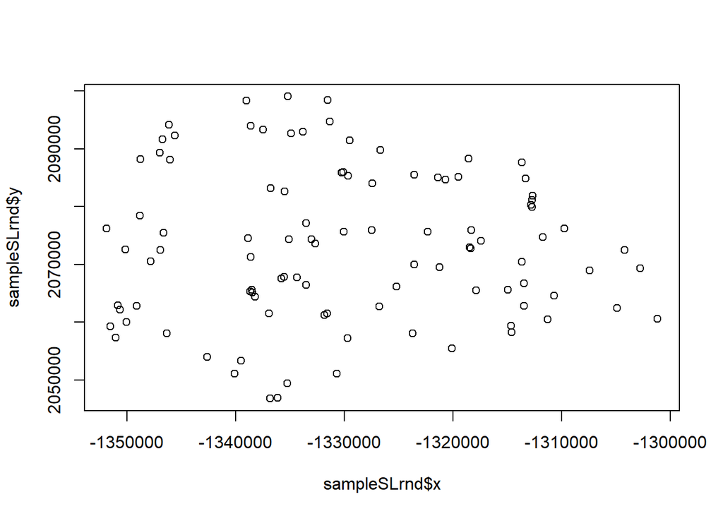

```r
plot(sampleSLrnd$x, sampleSLrnd$y)
```

4). Spatial Correlation

```r
library(ape)
flat_data <- as.data.frame(sampleSLrnd)
dist_matrix <- as.matrix(dist(cbind(flat_data$x, flat_data$y)))
dist_matix.inv <- 1/dist_matrix
diag(dist_matix.inv) <- 0
Moran.I(sampleSLrnd$Rd_dns1km_SL, dist_matix.inv)
```

```
## $observed
## [1] 0.2202208
##
## $expected
## [1] -0.01010101
##
## $sd
## [1] 0.02318771
##
## $p.value
## [1] 0
```

5). Urban Change Pixels Identification between 2001 and 2016

```r
allrastersSL <- allrastersSL %>%
    mutate(urbanChg = (NLCD_2001_SL != 21 & NLCD_2001_SL != 22 & NLCD_2001_SL != 23 & NLCD_2001_SL != 24) &  (NLCD_2016_SL == 21 | NLCD_2016_SL == 22  | NLCD_2016_SL == 23 | NLCD_2016_SL == 24))

## calculate total new urban impervious for 2016
newUrban <- (sum(as.numeric(allrastersSL$NLCD_2016_SL == 21 | allrastersSL$NLCD_2016_SL == 22 |allrastersSL$NLCD_2016_SL == 23 | allrastersSL$NLCD_2016_SL == 24))) - (sum(as.numeric(allrastersSL$NLCD_2001_SL == 21| allrastersSL$NLCD_2001_SL == 22| allrastersSL$NLCD_2001_SL == 23| allrastersSL$NLCD_2001_SL == 24)))
## calculate total urban impervious for 2001
urban2001 <- (sum(as.numeric(allrastersSL$NLCD_2001_SL == 21| allrastersSL$NLCD_2001_SL == 22| allrastersSL$NLCD_2001_SL == 23| allrastersSL$NLCD_2001_SL == 24)))
## percentage increase in urban impervious
newUrban/urban2001* 100
```

```
## [1] 15.88895
```

6). Values Comparison between urban change pixels and non urban change pixels

```r
library(plyr)
library(reshape2)
```

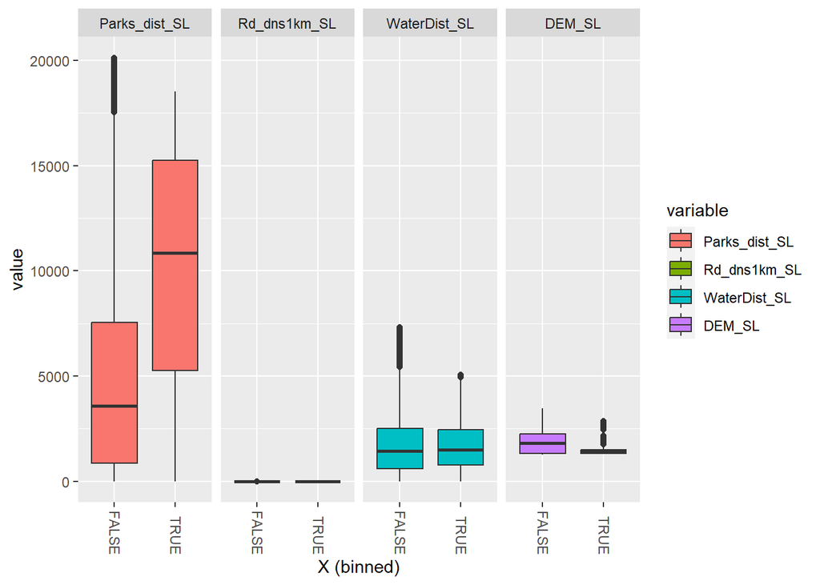

```r
library(plotly)
SL <- allrastersSL %>%
  filter(NLCD_2001_SL != 21 & NLCD_2001_SL != 22 & NLCD_2001_SL != 23 & NLCD_2001_SL != 24)
SL <- SL[10:14]
SLmelt<-melt(SL)
p <- ggplot(SLmelt, aes(x=urbanChg, y=value,fill=variable))+
    geom_boxplot()+
    facet_grid(.~variable)+
    labs(x="X (binned)")+
    theme(axis.text.x=element_text(angle=-90, vjust=0.4,hjust=1))
p
```

7). Split train and test Dataset

```r
###Grab all the developed cells (presence)
newUrban <- SL %>%
  filter(urbanChg == TRUE)

###Grab all the nondeveloped and not previously urban cells (absence)
nonUrban <- SL %>%
  filter(urbanChg == FALSE)

###Get a random sample of the absence data
### that is twice as large as the presence data
index <- sample(1:nrow(nonUrban), (round(nrow(newUrban)* 2)))
SLsampleUrban <- nonUrban[index, ]

### combine the orginal presence and absence data
SLsample <- rbind(SLsampleUrban, newUrban)

index <- sample(1:nrow(SLsample), (round(nrow(SLsample)* 0.01)))
SLsample <- SLsample[index, ]

SLsample <- SLsample %>%
  mutate(urbanChgTF = ifelse(urbanChg == TRUE , 1,
               ifelse(urbanChg == FALSE, 0, NA)))


SLsample <- SLsample %>% dplyr::mutate(id = row_number())
train <- SLsample %>% sample_frac(.70)
test  <- anti_join(SLsample, train, by = 'id')
```

8). Build Random Forest Model

Reassign the “TRUE” or “FALSE” value of urbanChg of ‘SLsample’ with “1” and “0”, and use `randomForest` function to fit the independent and dependent variables using train dataset

```r
library(randomForest)
set.seed(15)


fit <- randomForest(urbanChg ~ Parks_dist_SL + Rd_dns1km_SL + WaterDist_SL +DEM_SL,data=train,importance=TRUE,proximity=TRUE,ntree=500)
```

Plot the model’s MSE by number of trees

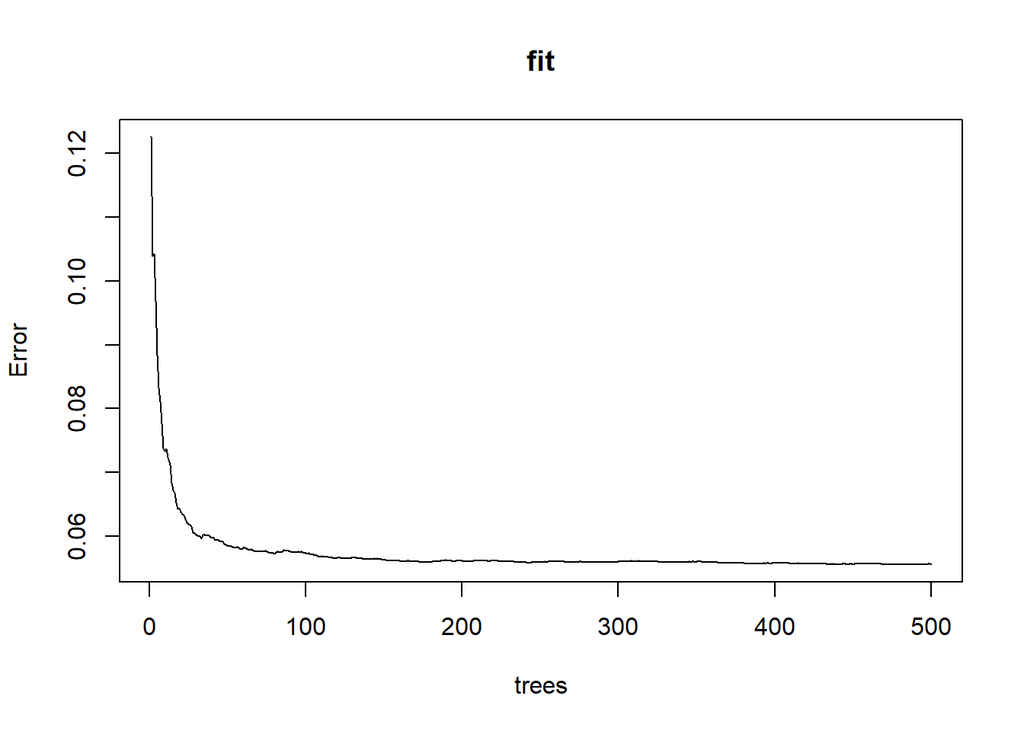

```r
plot(fit)
```

3). Tune the Model Using `tuneRF` function to test out the best parameter of the random forest model

```r
model_tuned <- tuneRF(
               x=train[,1:4],
               y=train$urbanChg,
               ntreeTry=500,
               mtryStart=4,
               stepFactor=1.5,
               improve=0.01,
               trace=FALSE
               )
```

```
## 0.01122873 0.01
```

```
## 0.01963843 0.01
```

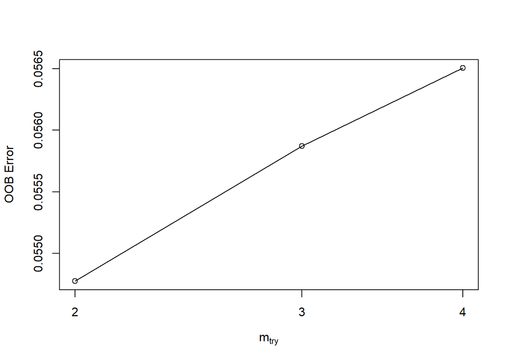

```r
library(ROCR)
```

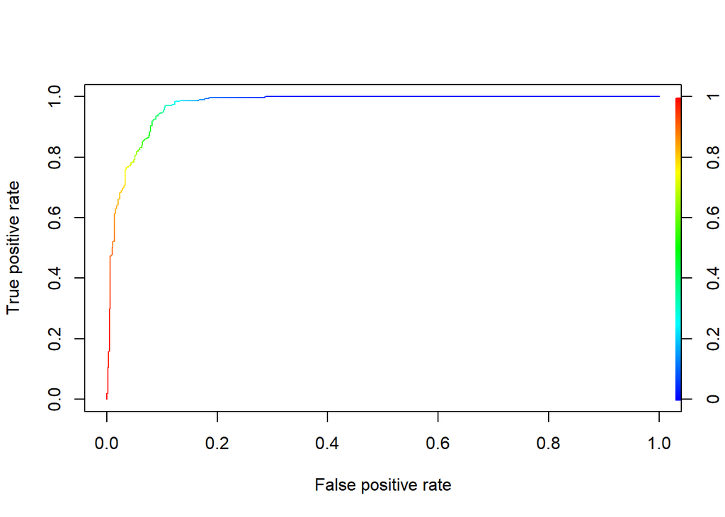

```r
# plot a ROC curve for a single prediction run
# and color the curve according to cutoff.
pred <- prediction(predict(fit,newdata=test), test$urbanChg)
perf <- performance(pred,"tpr","fpr")
plot(perf,colorize=TRUE)
```

```r
## A simpler way to understand these result is to calculate the
## area under the curve(AUC). The closer this number is to 1, the
## better your model fit
auc_ROCR <- performance(pred, measure = "auc")
auc_ROCR <- auc_ROCR@y.values[[1]]
auc_ROCR
```

```
## [1] 0.9727233
```

5). Importance of variables

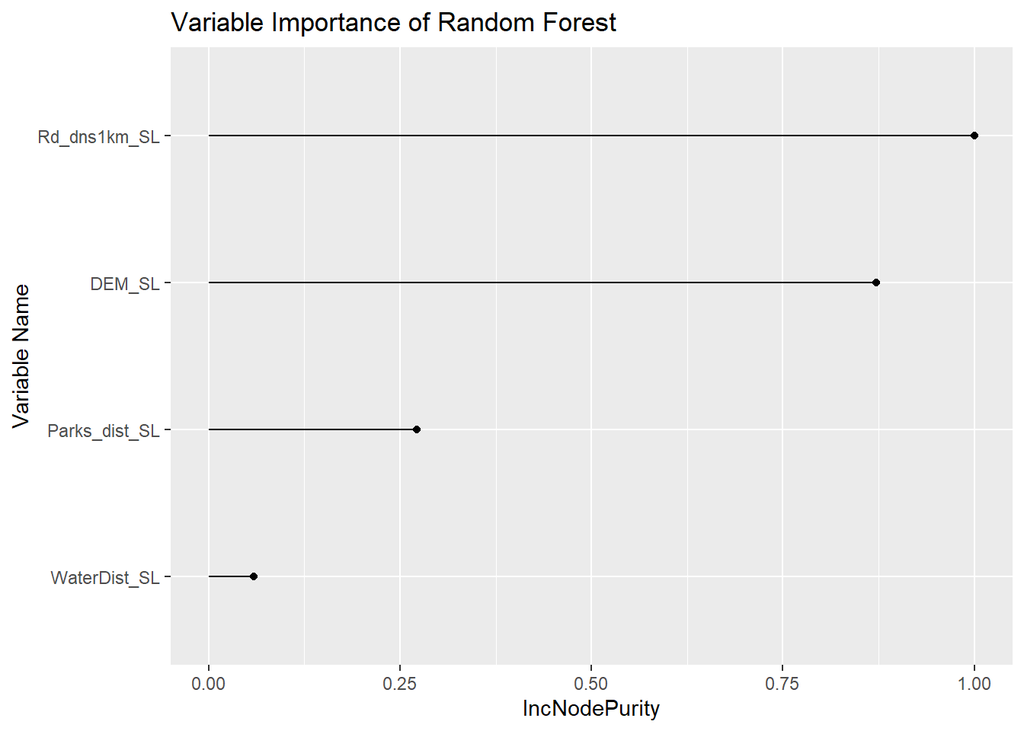

```r
imp <- importance(fit)
imp <- (imp - min(imp)) / (max(imp) - min(imp))
imp <- as.data.frame(imp)
imp$varnames <- rownames(imp)
rownames(imp) <- NULL

ggplot(imp, aes(x=reorder(varnames, IncNodePurity), y=IncNodePurity)) +
  geom_point() +
  geom_segment(aes(x=varnames,xend=varnames,y=0,yend=IncNodePurity)) +
  scale_color_discrete(name="Variable Group") +
  ylab("IncNodePurity") +
  xlab("Variable Name") +
  coord_flip()+
  ggtitle("Variable Importance of Random Forest")
```

6). Prediction use `predict` function to predict the urban change area.

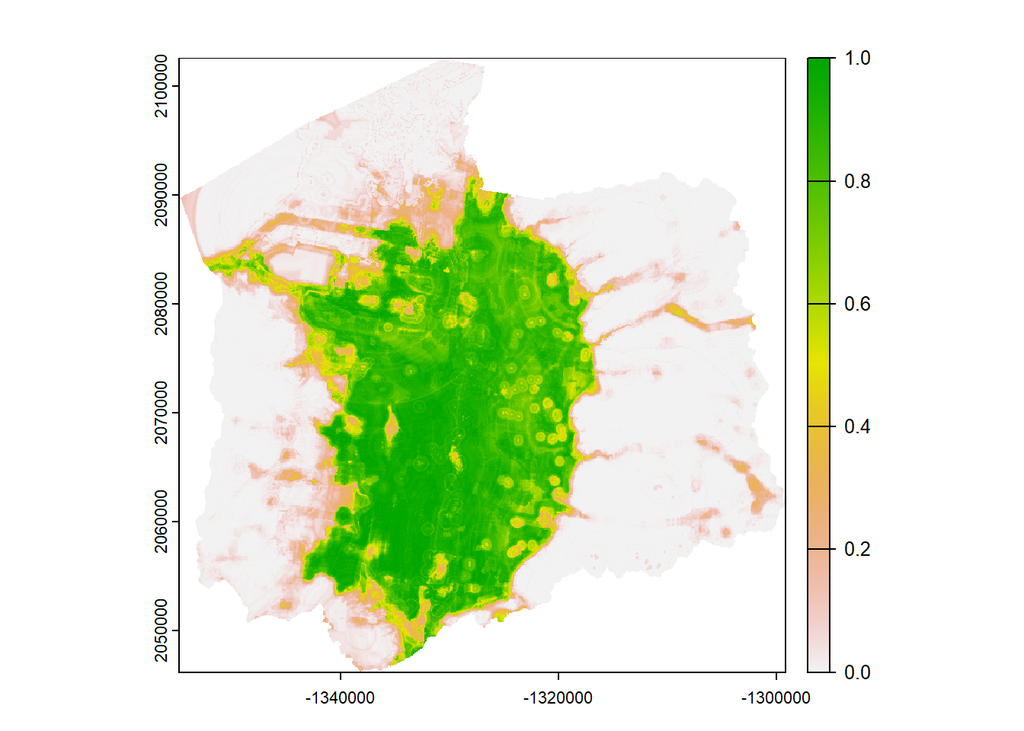

```r
predicted <- predict(allrasters,fit)
plot(predicted)
```

We can see that the suitability of Salt Lake City is mainly distributed in the center area, and roads in the city can extend the suitability of the urban area’s development, and we can see that the density of roads of the west part of the city is greater than the east part, and the roads in the western region are more connected than the east part as well, which might indicate the city’s development in the future will be western-orientated. Besides the variables we used in this case, I think we can add variables like the population of the city in grid format, the distance to nearest super markets/movie theaters/parks in the Salt Lake City to better improve the performance of simulation of urban area development.

2. Analyze the database of amenity landscape characteristics using a clustering technique. Choose variables based on a thematic inquiry of your choice. Visualize ad provide qualitative descriptions of the groups that you derive from the clustering techniques. Provide evidence of you characterizations. Provide a map of your cluster analysis. Give an explanation of the spatial distribution of these groups. (1-2 paragraphs)

I choose to explore the spatial patterns of historical landscape characteristics of the US including Historical Structures, Historical Objects, Historical district, Historical buildings and Historical Sites, to better reflect the historical characteristics of a pixel, hotels, population, urban percentage, etc. are taken into account as well.

1). Read Data

```r
library(fastcluster)
```

```r
library(graphics)
library(ggplot2)
library(ggdendro)
library(sf)
amenData<- st_read("AmenDataAll.shp")
geomData = st_sfc(amenData$geometry)
```

2). Data Pre-processing

Normalize total number of Flickr photographs by population, and omit NA values and calculate the Z-score(This allows for equitable comparisons between different variables when determining clusters, particularly critical in k-means clustering where the algorithm is distance-based)

```r
amenData$SocialNorm <- amenData$Nat_Flickr/(amenData$serPop10 + 1)
amenData$HousingChg <- amenData$Urb2011 - amenData$Urb2001

amenDataDF<-amenData[,c("SocialNorm", "HousingChg", "HotelTOT", "Urb2001","HistStruc", "HistObject","HistSite", "Histdistr", "Histbuild","ser00publi", "serhous90" )]

## make sure there are no missing data
amenDataDF <- na.omit(amenDataDF)
amenDataDF <- as.data.frame(amenDataDF)[1:11]
## calculate z-scores for the dataset
db_scaled <- scale(amenDataDF)
```

```r
wss <- (nrow(db_scaled)-1)*sum(apply(db_scaled,2,var))
for (i in 2:15) wss[i] <- sum(kmeans(db_scaled,
   centers=i)$withinss)
```

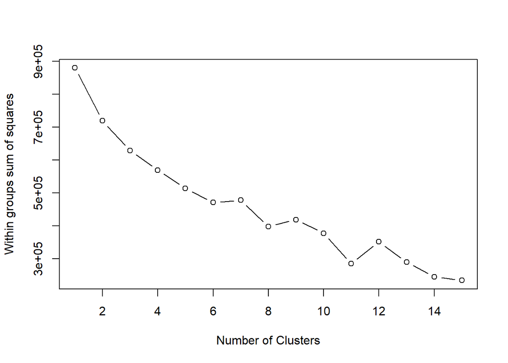

```r
plot(1:15, wss, type="b", xlab="Number of Clusters",
  ylab="Within groups sum of squares")
```

4). k-means clustering

```r
fit <- kmeans(db_scaled, 4)
# get cluster means
aggregate(db_scaled,by=list(fit$cluster),FUN=mean)
```

```
##   Group.1  SocialNorm  HousingChg   HotelTOT     Urb2001   HistStruc HistObject
## 1       1 -0.06800312 -2.66338320  1.6073065  2.66338320  0.71119897 -0.0462826
## 2       2  0.19168779  0.66990040 -0.1410613 -0.66990040 -0.09480900 -0.0462826
## 3       3 -0.05962110  0.02771617 -0.1087826 -0.02771617 -0.04053574 -0.0462826
## 4       4 -0.04212002 -1.53271103  1.2536230  1.53271103  1.64301769 20.1792134
##      HistSite   Histdistr   Histbuild ser00publi  serhous90
## 1  0.45315232  0.81954234  1.45315263 -0.4940340  2.5740160
## 2 -0.03889716 -0.06949067 -0.16644853  1.7698978 -0.3344361
## 3 -0.03399094 -0.05988859 -0.09020309 -0.5634494 -0.1367474
## 4  1.26715508  1.72253139  2.73806090 -0.3345347  2.0223946
```

5). Spatially Plot the Results

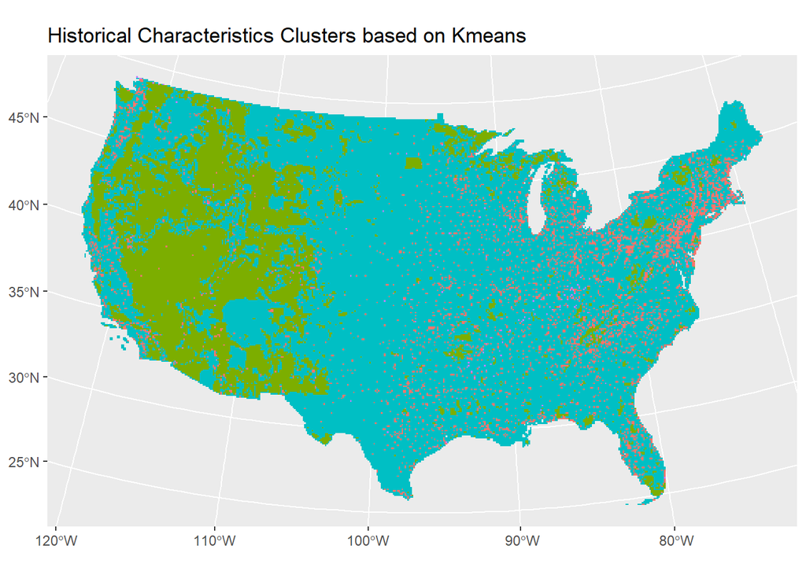

```r
amenData <- data.frame(amenData, fit$cluster)
st_geometry(amenData) <- geomData
ggplot() +
  geom_sf(data = amenData, mapping = aes(fill = as.factor(fit.cluster)), color = NA) +
  theme(legend.position = "none") +
  ggtitle("Historical Characteristics Clusters based on Kmeans")
```